# Jenis Layanan Cloud

15 Maret 2024

## Do’a Belajar

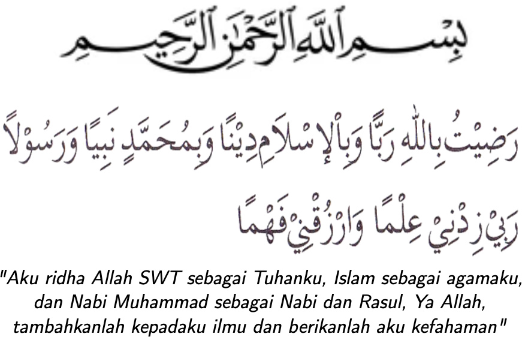

## Layanan Cloud Computing

## Layanan Cloud Computing

Sebuah cloud bisa berlabel privat atau publik. Public Cloud menjual layanan ke siapapun di internet. (Saat ini, Amazon Web Service merupakan provider public cloud terbesar.) Private Cloud adalah jaringan proprietary atau data center yang mensuplay layanan-layanan ter-host kepada orang-orang dalam jumlah terbatas. Jika sebuah service provider menggunakan sumber-sumber milik private cloud, maka hasilnya disebut virtual private cloud. Private atau publik, tujuan dari cloud computing adalah menyediakan akses yang mudah, skalabel kepada sumber-sumber komputasi dan layanan TI.

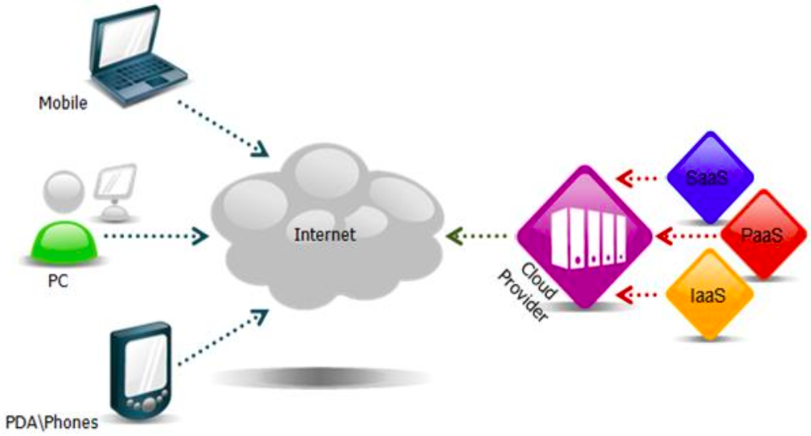

## Software as a Service (SaaS)

Model ini memberikan user sebuah aplikasi bisnis yang diakses melalui web. Umumnya user melakukan sewa aplikasi sehingga dapat mengakses fitur- fitur yang ada, user juga dapat membayar biaya tambahan untuk mengakses kapasitas / fitur yang lebih banyak. Dengan naiknya teknologi web seperti AJAX, memungkinkan web memiliki tingkat user experience yang mendekati desktop application.

[figure not shown]

## Platform as a Service (PaaS)

Disini, konsumen diberikan sebuah platform untuk pengembangan sampai implementasi sistem. Konsumen harus membuat dan mengimplementasikan sistemnya sendiri. Umumnya tools untuk development disediakan dalam bentuk web application.

PaaS umumnya memiliki fitur sebagai berikut:

- Development tools berbasis browser internet
- Skalabilitas, access control, security, dan web service tersedia
- Integrasi yang mudah dengan aplikasi lain selama pada platform yang sama
- Tersedia connector untuk terhubung dengan sistem lain diluar komputasi cloud

[figure not shown]

## Infrastructure as a Service (IaaS)

Model ini hanya memberikan user aspek dasar dari computing seperti jaringan, storage, prosessor untuk computing. Infrastruktur komputasi cloud sangat bergantung pada virtualisasi.

IaaS umumnya memiliki fitur:

- memiliki pilihan virtual machine yang beragam, baik yang sama sekali kosong, memiliki OS preinstalled, bahka telah memiliki beberapa office productivity tools terinstall
- dapat meningkatkan atau menurunkan kemampuan computing baik secara manual atau otomatis (optimization)
- terdapat tools untuk memproses banyak data ataupun memproses aplikasi dengan perhitungan yang rumit
- dapat menyimpan data pada beberapa lokasi geografis fisik (memudahkan download)

## Penutup

[figure not shown]